# CCPS 844 Data Mining Project

#### *Classification algorithms run with PCA dimension of 1*

```python
# allocate data to X and y variables
X = X_pca1
y = data['survived']
```

```python
# split data into training and test sets
from sklearn.model_selection import train_test_split
X_train, X_test, y_train, y_test = train_test_split( X, y, test_size = 0.25, random_state = 100)
```

```
Decision Tree Confusion Matrix:
[[131  79]
 [ 84  34]]
```

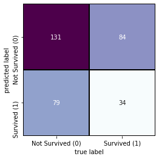

```
Decision Tree Classification Report:
              precision    recall  f1-score   support

         0.0       0.61      0.62      0.62       210
         1.0       0.30      0.29      0.29       118

    accuracy                           0.50       328
   macro avg       0.46      0.46      0.46       328
weighted avg       0.50      0.50      0.50       328





Naives Bayes Confusion Matrix:
[[196  14]
 [107  11]]
```

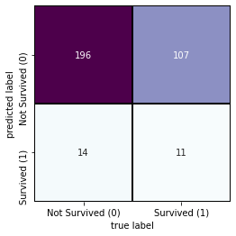

```
Naives Bayes Classification Report:
              precision    recall  f1-score   support

         0.0       0.65      0.93      0.76       210
         1.0       0.44      0.09      0.15       118

    accuracy                           0.63       328
   macro avg       0.54      0.51      0.46       328
weighted avg       0.57      0.63      0.54       328





KNeighbor Classification Confusion Matrix:
[[151  59]
 [ 81  37]]
```

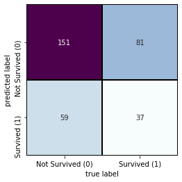

```
KNeighbor Classification Classification Report:
              precision    recall  f1-score   support

         0.0       0.65      0.72      0.68       210
         1.0       0.39      0.31      0.35       118

    accuracy                           0.57       328
   macro avg       0.52      0.52      0.51       328
weighted avg       0.56      0.57      0.56       328





Logistic Regression Confusion Matrix:
[[194  16]
 [104  14]]
```

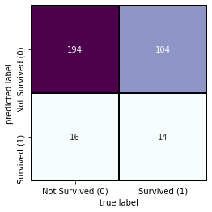

```
Logistic Regression Classification Report:
              precision    recall  f1-score   support

         0.0       0.65      0.92      0.76       210
         1.0       0.47      0.12      0.19       118

    accuracy                           0.63       328
   macro avg       0.56      0.52      0.48       328
weighted avg       0.58      0.63      0.56       328





Random Forest Confusion Matrix:
[[131  79]
 [ 84  34]]
```

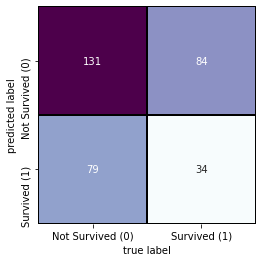

```
Random Forest Classification Report:
              precision    recall  f1-score   support

         0.0       0.61      0.62      0.62       210
         1.0       0.30      0.29      0.29       118

    accuracy                           0.50       328
   macro avg       0.46      0.46      0.46       328
weighted avg       0.50      0.50      0.50       328





SVM Classifcation Confusion Matrix:
[[185  25]
 [ 96  22]]
```

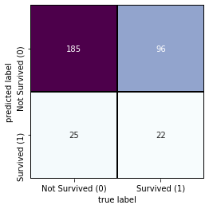

```
SVM Classifcation Classification Report:
              precision    recall  f1-score   support

         0.0       0.66      0.88      0.75       210
         1.0       0.47      0.19      0.27       118

    accuracy                           0.63       328
   macro avg       0.56      0.53      0.51       328
weighted avg       0.59      0.63      0.58       328





Kernel SVM Classification Confusion Matrix:
[[199  11]
 [110   8]]
```

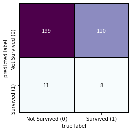

```
Kernel SVM Classification Classification Report:
              precision    recall  f1-score   support

         0.0       0.64      0.95      0.77       210
         1.0       0.42      0.07      0.12       118

    accuracy                           0.63       328
   macro avg       0.53      0.51      0.44       328
weighted avg       0.56      0.63      0.53       328
```

```python
# call functon that will run classifcation algoritms
callClassFunctions(X,y)
```

Running the classification algorithms based on PCA with dimension of 1 produced the following results.

| Algortithm | Class 0 Precision | Accuracy |
| --- | --- | --- |
| Decision Tree | 61% | 50% |
| Naives Bayes | 65% | 63% |
| KNeighbor | 65% | 57% |
| Logistic Regression | 65% | 63% |
| Random Forest | 61% | 50% |
| SVM | 66% | 63% |
| Kernel SVM | 64% | 63% |

Again, none of the algortihms performed particularly well in this instance. However, Naives Bayes, Logitic Regression, SVM and Kernel SVM performed equally with an accuracy of 63%. SVM had the highest class 0 precision of 66%. The other's class 0 precision were around 64% and 65%.

We will now test the accuracy of the algorithms using 10-fold cross validation.

```
Mean accuracy score of classification models using 10-fold Cross-Validation:

Decision Tree:  Mean-0.627   Standard Deviation-(0.053)
Naives Bayes:  Mean-0.660   Standard Deviation-(0.066)
KNeighbor Classification:  Mean-0.600   Standard Deviation-(0.051)
Logistic Regression:  Mean-0.657   Standard Deviation-(0.061)
Random Forest:  Mean-0.626   Standard Deviation-(0.052)
SVM Classifcation:  Mean-0.655   Standard Deviation-(0.084)
Kernel SVM Classification:  Mean-0.642   Standard Deviation-(0.038)
```

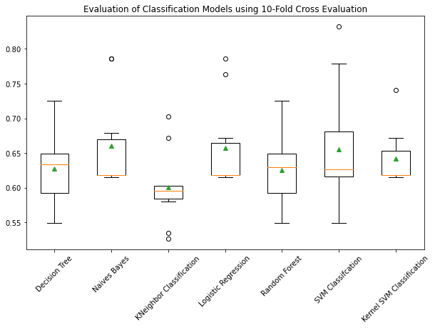

```python
# create list of models to evaluate and call function to evaluate models
modelsToEval = (DT, NB, KNN, LOGR, RF, SVMC, K_SVMC)
evalClassModels(modelsToEval)
```

Testing the accuracy of the algorithms produced the following results:

| Algortithm | Mean Accuracy | Standard Deviation |
| --- | --- | --- |
| Decision Tree | 62% | 5.3% |
| Naives Bayes | 66% | 6.6% |
| KNeighbor | 60% | 5.1% |
| Logistic Regression | 65% | 6.1% |
| Random Forest | 62% | 5.2% |
| SVM | 65% | 8.4% |
| Kernel SVM | 64% | 3.8% |

In this case the training algoritms performed well. The test of the accuracy scores were consistent with the accuracy scores of the training algorithms.

## **Concluding Evaluation of Classification Algorithms**

From the training algorithms based on RFECV and RFE, we were not able to conclude what were the best features that would increase the probility of survival. Clearly, whether one had a lifeboat was a factor, but also sex, class, embarked and siblings had an impact.

## **Regression Algorithms**

We will run our regression algorithms based on the optimal features from the RFECV using the logistic regression estimator, then the RFECV with the random forest estimator, followed by RFECV with the decision tree estimator, RFE, PCA with component = 5 and PCA with component = 1. We will then compare the results of the algorithm to determine which produced the best results. While we will compare a number of scoring metrics, we will use the MSE score as the basis for determining which algorithm and, its associated feature selections, performed the best.  
The regression algorithms that we will consider are as follows:

1. Linear Regression
2. K-Nearest Neighbor
3. SVM Regression
4. Kernel SVM

We will evaluate the accuracy of the MSE and RMSE of each model by applying K-fold Cross Validation to the model.

#### *Regression algorithm run on 5 optimal features from RFECV with logistic regression*

```python
# allocate data to X and y variables
X = data.loc[:, ['boat','embarked', 'pclass','sex', 'sibsp']]
y = data['survived']
```

```python
# split data into training and test sets
from sklearn.model_selection import train_test_split
X_train, X_test, y_train, y_test = train_test_split( X, y, test_size = 0.25, random_state = 100)
```

```python
# call functon that will run classifcation algoritms
callRegFunctions(X,y)
```

```
 Linear Regression intercept and coefficient:


0.46123967894287166
[ 0.00806617  0.03781326 -0.14617118  0.45099329 -0.02655568]


Linear Regression Error Calculations:

Linear Regression Variance score: -0.54
Linear Regression MAE: : 0.49
Linear Regression MSE: : 0.35
Linear Regression RMSE: : 0.59


KNeighbor Regression Error Calculations:

KNeighbor Regression Variance score: -1.11
KNeighbor Regression MAE: : 0.50
KNeighbor Regression MSE: : 0.49
KNeighbor Regression RMSE: : 0.70


SVM Regression Error Calculations:

SVM Regression Variance score: -0.82
SVM Regression MAE: : 0.50
SVM Regression MSE: : 0.42
SVM Regression RMSE: : 0.65


Kernel SVM Regression Error Calculations:

Kernel SVM Regression Variance score: -0.78
Kernel SVM Regression MAE: : 0.49
Kernel SVM Regression MSE: : 0.41
Kernel SVM Regression RMSE: : 0.64
```

```python
# define Regression model variables globally
LIN = "Linear Regression"
REGKNN = "KNeighbor Regression"
RSVM = "SVM Regression"
K_RSVM = "Kernel SVM Regression"


# create list of models to evaluate and call function to evaluate models
modelsRegToEval = (LIN, REGKNN, RSVM, K_RSVM)
evalRegModels(modelsRegToEval)
```

```
Regression Model Metrics:

K-fold Linear RegressionMSE: 0.13
K-fold Linear RegressionRMSE: 0.36


K-fold KNeighbor RegressionMSE: 0.09
K-fold KNeighbor RegressionRMSE: 0.30


K-fold SVM RegressionMSE: 0.08
K-fold SVM RegressionRMSE: 0.28


K-fold Kernel SVM RegressionMSE: 0.08
K-fold Kernel SVM RegressionRMSE: 0.28
```

Testing the accuracy of the regression algorithms produced the following results:

| Algortithm | Training MSE | MSE from 10-fold CV |
| --- | --- | --- |
| Linear Regression | 35% | 13% |
| KNeighbor | 49% | 9% |
| SVM | 42% | 8% |
| Kernel SVM | 41% | 8% |

In this case the training algorithm Linear Regression performed the best as its MSE was the lowest of the group of algrotihms. However, the test of the accuracy scores indicate that SVM should have been the better performing algorithm.

#### *Regression algorithm run on 1 optimal feature (boat) from RFECV with random forest and decision tree*

Recall both produced 'boat' as the optional feature

```python
# allocate data to X and y variables
X = data.loc[:, ['boat']]
y = data['survived']
```

```python
# split data into training and test sets
from sklearn.model_selection import train_test_split
X_train, X_test, y_train, y_test = train_test_split( X, y, test_size = 0.25, random_state = 100)
```

```python
# call functon that will run classifcation algorithms
callRegFunctions(X,y)
```

```
 Linear Regression intercept and coefficient:


0.31575270197254723
[0.00966386]


Linear Regression Error Calculations:

Linear Regression Variance score: -0.25
Linear Regression MAE: : 0.49
Linear Regression MSE: : 0.29
Linear Regression RMSE: : 0.54


KNeighbor Regression Error Calculations:

KNeighbor Regression Variance score: -0.65
KNeighbor Regression MAE: : 0.56
KNeighbor Regression MSE: : 0.38
KNeighbor Regression RMSE: : 0.62


SVM Regression Error Calculations:

SVM Regression Variance score: -0.82
SVM Regression MAE: : 0.50
SVM Regression MSE: : 0.42
SVM Regression RMSE: : 0.65


Kernel SVM Regression Error Calculations:

Kernel SVM Regression Variance score: -0.73
Kernel SVM Regression MAE: : 0.49
Kernel SVM Regression MSE: : 0.40
Kernel SVM Regression RMSE: : 0.63
```

```python
# create list of models to evaluate and call function to evaluate models
modelsRegToEval = (LIN, REGKNN, RSVM, K_RSVM)
evalRegModels(modelsRegToEval)
```

```
Regression Model Metrics:

K-fold Linear RegressionMSE: 0.20
K-fold Linear RegressionRMSE: 0.45


K-fold KNeighbor RegressionMSE: 0.08
K-fold KNeighbor RegressionRMSE: 0.28


K-fold SVM RegressionMSE: 0.08
K-fold SVM RegressionRMSE: 0.28


K-fold Kernel SVM RegressionMSE: 0.07
K-fold Kernel SVM RegressionRMSE: 0.27
```

Testing the accuracy of the regression algorithms produced the following results:

[output not shown]

#### *Regression algorithms run with all features*

```python
# allocate data to X and y variables
X = data.drop('survived',axis=1).astype(float)
y = data['survived']
```

```python
# split data into training and test sets
from sklearn.model_selection import train_test_split
X_train, X_test, y_train, y_test = train_test_split( X, y, test_size = 0.25, random_state = 100)
```

```python
# call functon that will run classifcation algorithms
callRegFunctions(X,y)
```

```
 Linear Regression intercept and coefficient:


0.6123132077849148
[-1.56819778e-01  4.41757558e-01 -4.24357025e-03 -3.56539092e-02
 -6.07021802e-03  3.73497813e-04  3.73949745e-02  7.90963302e-03]


Linear Regression Error Calculations:

Linear Regression Variance score: -0.54
Linear Regression MAE: : 0.49
Linear Regression MSE: : 0.36
Linear Regression RMSE: : 0.60


KNeighbor Regression Error Calculations:

KNeighbor Regression Variance score: -0.94
KNeighbor Regression MAE: : 0.49
KNeighbor Regression MSE: : 0.45
KNeighbor Regression RMSE: : 0.67


SVM Regression Error Calculations:

SVM Regression Variance score: -0.70
SVM Regression MAE: : 0.48
SVM Regression MSE: : 0.39
SVM Regression RMSE: : 0.63


Kernel SVM Regression Error Calculations:

Kernel SVM Regression Variance score: -0.46
Kernel SVM Regression MAE: : 0.48
Kernel SVM Regression MSE: : 0.34
Kernel SVM Regression RMSE: : 0.58
```

```python
# create list of models to evaluate and call function to evaluate models
modelsRegToEval = (LIN, REGKNN, RSVM, K_RSVM)
evalRegModels(modelsRegToEval)
```

```
Regression Model Metrics:

K-fold Linear RegressionMSE: 0.13
K-fold Linear RegressionRMSE: 0.36


K-fold KNeighbor RegressionMSE: 0.14
K-fold KNeighbor RegressionRMSE: 0.37


K-fold SVM RegressionMSE: 0.11
K-fold SVM RegressionRMSE: 0.33


K-fold Kernel SVM RegressionMSE: 0.14
K-fold Kernel SVM RegressionRMSE: 0.37
```

Testing the accuracy of the regression algorithms produced the following results:

| Algortithm | Training MSE | MSE from 10-fold CV |
| --- | --- | --- |
| Linear Regression | 36% | 13% |
| KNeighbor | 45% | 14% |
| SVM | 39% | 11% |
| Kernel SVM | 34% | 14% |

#### *Regression algorithms run with PCA dimension reduction of 5*

```python
# allocate data to X and y variables
X = pd.DataFrame(X_pca5)
y = data['survived']
```

```python
# split data into training and test sets
from sklearn.model_selection import train_test_split
X_train, X_test, y_train, y_test = train_test_split( X, y, test_size = 0.25, random_state = 100)
```

```python
# call functon that will run classifcation algoritms
callRegFunctions(X,y)
```

```
 Linear Regression intercept and coefficient:


0.3891143106511416
[ 0.00228767  0.00971821 -0.00097747 -0.03796754  0.03741391]


Linear Regression Error Calculations:

Linear Regression Variance score: -0.31
Linear Regression MAE: : 0.48
Linear Regression MSE: : 0.30
Linear Regression RMSE: : 0.55


KNeighbor Regression Error Calculations:

KNeighbor Regression Variance score: -0.98
KNeighbor Regression MAE: : 0.49
KNeighbor Regression MSE: : 0.46
KNeighbor Regression RMSE: : 0.68


SVM Regression Error Calculations:

SVM Regression Variance score: -0.70
SVM Regression MAE: : 0.48
SVM Regression MSE: : 0.39
SVM Regression RMSE: : 0.63


Kernel SVM Regression Error Calculations:

Kernel SVM Regression Variance score: -0.41
Kernel SVM Regression MAE: : 0.47
Kernel SVM Regression MSE: : 0.32
Kernel SVM Regression RMSE: : 0.57
```

```python
# create list of models to evaluate and call function to evaluate models
modelsRegToEval = (LIN, REGKNN, RSVM, K_RSVM)
evalRegModels(modelsRegToEval)
```

```
Regression Model Metrics:

K-fold Linear RegressionMSE: 0.19
K-fold Linear RegressionRMSE: 0.43


K-fold KNeighbor RegressionMSE: 0.14
K-fold KNeighbor RegressionRMSE: 0.37


K-fold SVM RegressionMSE: 0.11
K-fold SVM RegressionRMSE: 0.33


K-fold Kernel SVM RegressionMSE: 0.15
K-fold Kernel SVM RegressionRMSE: 0.39
```

Testing the accuracy of the regression algorithms produced the following results:

[output not shown]

In this case the training algoritms Linear Regression performed the best as its MSE was the lowest of the group of algrotihms. However, the test of the accuracy scores indicate that SVM should have been the better performing algorithm.

#### *Regression algorithm run with PCA dimension reduction of 1*

```python
# allocate data to X and y variables
X = pd.DataFrame(X_pca1)
y = data['survived']
```

```python
# split data into training and test sets
from sklearn.model_selection import train_test_split
X_train, X_test, y_train, y_test = train_test_split( X, y, test_size = 0.25, random_state = 100)
```

```python
# call functon that will run classifcation algoritms
callRegFunctions(X,y)
```

```
 Linear Regression intercept and coefficient:


0.3858969187548958
[0.00225459]


Linear Regression Error Calculations:

Linear Regression Variance score: -0.06
Linear Regression MAE: : 0.47
Linear Regression MSE: : 0.24
Linear Regression RMSE: : 0.49


KNeighbor Regression Error Calculations:

KNeighbor Regression Variance score: -0.58
KNeighbor Regression MAE: : 0.45
KNeighbor Regression MSE: : 0.36
KNeighbor Regression RMSE: : 0.60


SVM Regression Error Calculations:

SVM Regression Variance score: -0.27
SVM Regression MAE: : 0.40
SVM Regression MSE: : 0.29
SVM Regression RMSE: : 0.54


Kernel SVM Regression Error Calculations:

Kernel SVM Regression Variance score: -0.36
Kernel SVM Regression MAE: : 0.43
Kernel SVM Regression MSE: : 0.31
Kernel SVM Regression RMSE: : 0.56
```

```python
# create list of models to evaluate and call function to evaluate models
modelsRegToEval = (LIN, REGKNN, RSVM, K_RSVM)
evalRegModels(modelsRegToEval)
```

```
Regression Model Metrics:

K-fold Linear RegressionMSE: 0.22
K-fold Linear RegressionRMSE: 0.47


K-fold KNeighbor RegressionMSE: 0.29
K-fold KNeighbor RegressionRMSE: 0.54


K-fold SVM RegressionMSE: 0.27
K-fold SVM RegressionRMSE: 0.52


K-fold Kernel SVM RegressionMSE: 0.28
K-fold Kernel SVM RegressionRMSE: 0.53
```

Testing the accuracy of the regression algorithms produced the following results:

| Algortithm | Training MSE | MSE from 10-fold CV |
| --- | --- | --- |
| Linear Regression | 24% | 22% |
| KNeighbor | 36% | 29% |
| SVM | 29% | 27% |
| Kernel SVM | 31% | 28% |

In this case the training algoritms Linear Regression performed the best as its MSE was the lowest of the group of algrotihms. The test of the accuracy scores from the 10-fold cross validation supports this conclusion.

#### *Regression algorithms run on 1 optimal feature (sex) from RFE*

```python
# allocate data to X and y variables
X = data.loc[:, ['sex']]
y = data['survived']
```

```python
# split data into training and test sets
from sklearn.model_selection import train_test_split
X_train, X_test, y_train, y_test = train_test_split( X, y, test_size = 0.25, random_state = 100)
```

```python
# call functon that will run classifcation algoritms
callRegFunctions(X,y)
```

```
 Linear Regression intercept and coefficient:


0.1916932907348243
[0.54070108]


Linear Regression Error Calculations:

Linear Regression Variance score: -0.33
Linear Regression MAE: : 0.47
Linear Regression MSE: : 0.31
Linear Regression RMSE: : 0.55


KNeighbor Regression Error Calculations:

KNeighbor Regression Variance score: -0.44
KNeighbor Regression MAE: : 0.42
KNeighbor Regression MSE: : 0.33
KNeighbor Regression RMSE: : 0.58


SVM Regression Error Calculations:

SVM Regression Variance score: -0.68
SVM Regression MAE: : 0.48
SVM Regression MSE: : 0.39
SVM Regression RMSE: : 0.62


Kernel SVM Regression Error Calculations:

Kernel SVM Regression Variance score: -0.68
Kernel SVM Regression MAE: : 0.48
Kernel SVM Regression MSE: : 0.39
Kernel SVM Regression RMSE: : 0.62
```

```python
# create list of models to evaluate and call function to evaluate models
modelsRegToEval = (LIN, REGKNN, RSVM, K_RSVM)
evalRegModels(modelsRegToEval)
```

```
Regression Model Metrics:

K-fold Linear RegressionMSE: 0.18
K-fold Linear RegressionRMSE: 0.42


K-fold KNeighbor RegressionMSE: 0.28
K-fold KNeighbor RegressionRMSE: 0.53


K-fold SVM RegressionMSE: 0.19
K-fold SVM RegressionRMSE: 0.43


K-fold Kernel SVM RegressionMSE: 0.19
K-fold Kernel SVM RegressionRMSE: 0.43
```

Testing the accuracy of the regression algorithms produced the following results:

| Algortithm | Training MSE | MSE form 10-fold CV |
| --- | --- | --- |
| Linear Regression | 31% | 18% |
| KNeighbor | 33% | 28% |
| SVM | 39% | 19% |
| Kernel SVM | 39% | 19% |

In this case the training algoritms Linear Regression performed the best as its MSE was the lowest of the group of algrotihms. The test of the accuracy scores from the 10-fold cross validation supports this conclusion.

## **Concluding Evaluation of Regression Algorithms**

From the training algorithms based on RFECV it was determined that having a lifeboat is the most optimal feature to impact the probabilty of survival or non-survival on the Titanic.

## **Final Conclusion**

In conclusion, PCA dimension 1 produced the most accurate results in the classification algorithms. It performed better than the RFECV and RFE feature selection. Therefore, it is concluded that PCA dimension 1 is the best option for dimension reduction.